# Reproducible Research - Project 1

## Loading and preprocessing the data

- loading the data

```r
unzip("Project1_data.zip")
activity_data = read.csv("activity.csv",header = T,na.strings = "NA")
```

- preprocessing the data

```r
str(activity_data)
```

```
## 'data.frame':    17568 obs. of  3 variables:
##  $ steps   : int  NA NA NA NA NA NA NA NA NA NA ...
##  $ date    : Factor w/ 61 levels "2012-10-01","2012-10-02",..: 1 1 1 1 1 1 1 1 1 1 ...
##  $ interval: int  0 5 10 15 20 25 30 35 40 45 ...
```

```r
activity_data$date = as.Date(as.character(activity_data$date))
str(activity_data)
```

```
## 'data.frame':    17568 obs. of  3 variables:
##  $ steps   : int  NA NA NA NA NA NA NA NA NA NA ...
##  $ date    : Date, format: "2012-10-01" "2012-10-01" ...
##  $ interval: int  0 5 10 15 20 25 30 35 40 45 ...
```

## Mean total number of steps taken per day

### Ignored missing values in dataset

- Calculate the total number of steps taken per day

```r
steps_perday <- aggregate(steps ~ date, data = activity_data, sum, na.rm = TRUE)
```

- Make a histogram of the total number of steps taken each day

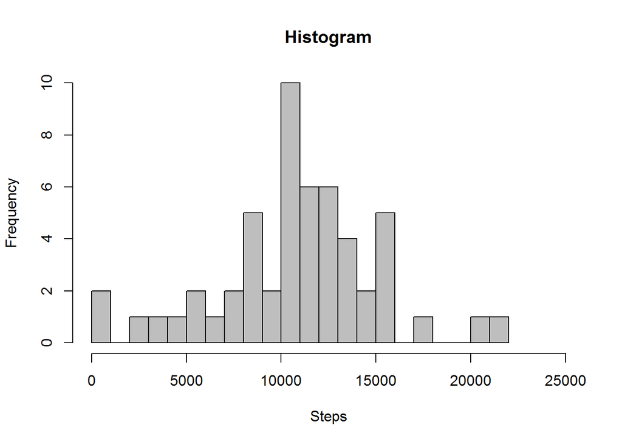

```r
hist(steps_perday$steps, col = "grey",breaks = 16,ylim = c(0,10),xlim = c(0,25000)
                                        ,xlab = "Steps", main = "Histogram")
```

- Calculate and report the mean and median of the total number of steps taken per day

```r
#day wise means and medians
daywise_means = aggregate(steps ~ date, data = activity_data, FUN = mean)
daywise_medians = aggregate(steps ~ date, data = activity_data, FUN = median)
#mean and median of total steps per day
mean(steps_perday$steps)
```

```
## [1] 10766.19
```

```r
median(steps_perday$steps)
```

```
## [1] 10765
```

## Daily activity pattern

- Time series plot of 5-minute interval and average number of steps taken, aaveraged across all days

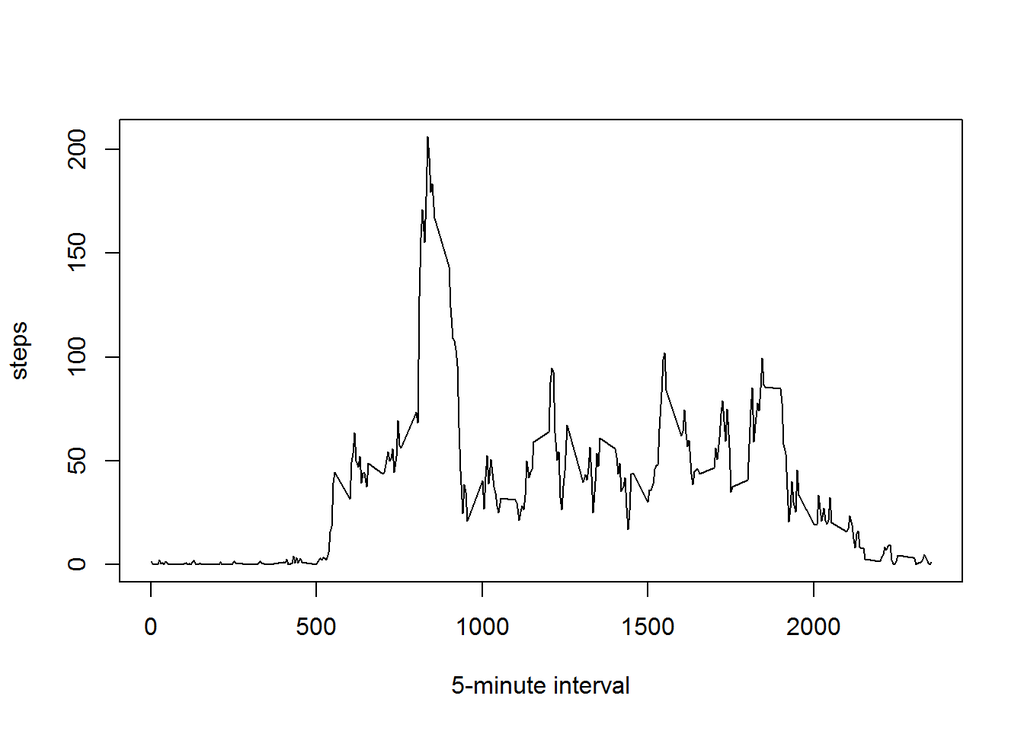

```r
steps_interval = aggregate(steps~interval, data = activity_data, FUN = mean)
with(steps_interval,plot(steps~interval,type = 'l', xlab = "5-minute interval"))
```

- 5-minute interval that contains maximun number of steps

```r
#which.max(steps_interval$steps)
#steps_interval[104,1]
max_steps_interval = steps_interval[which.max(steps_interval$steps),1]
max_steps_interval
```

```
## [1] 835
```

## Imputing missing values

- Calculate and report the total number of missing values in the dataset

```r
missing_values = sum(is.na(activity_data))
missing_values
```

```
## [1] 2304
```

- Strategy for filling in all of the missing values in the dataset

  I tried to impute NAs with the mean of steps variable but that strategy bought lot of variation from original dataset. Then I tried to impute NAs with their 5-minute interval’s steps mean(averages from the time intervals). Step wise strategy explained in code.

```r
head(activity_data)
```

```
##   steps       date interval
## 1    NA 2012-10-01        0
## 2    NA 2012-10-01        5
## 3    NA 2012-10-01       10
## 4    NA 2012-10-01       15
## 5    NA 2012-10-01       20
## 6    NA 2012-10-01       25
```

```r
#created 2 new dataframes with and without missing values
activity_data_NA = activity_data[is.na(activity_data),]
activity_data_noNA = activity_data[!is.na(activity_data),]

#inserting 5-minute interval's steps mean into all corresponding NAs
activity_data_NA$steps = steps_interval$steps

#checking for NAs
sum(is.na(activity_data_NA))
```

```
## [1] 0
```

```r
#binding the dataframes after imputing NAs to form a new dataframe
activity_data_imputed = rbind(activity_data_NA,activity_data_noNA)

#forming a propper ordered dataframe as before (activity_data)
activity_data_imputed = activity_data_imputed[order(activity_data_imputed[,2],
                                                    activity_data_imputed[,3]),]
```

“Forming a new data set” was also explained above for better understanding of imputing missing values.

```r
#binding the dataframes after imputing NAs to form a new dataframe
activity_data_imputed = rbind(activity_data_NA,activity_data_noNA)

#forming a propper ordered dataframe as before (activity_data)
activity_data_imputed = activity_data_imputed[order(activity_data_imputed[,2],
                                                    activity_data_imputed[,3]),]
head(activity_data_imputed)
```

```
##       steps       date interval
## 1 1.7169811 2012-10-01        0
## 2 0.3396226 2012-10-01        5
## 3 0.1320755 2012-10-01       10
## 4 0.1509434 2012-10-01       15
## 5 0.0754717 2012-10-01       20
## 6 2.0943396 2012-10-01       25
```

- Histogram of the total number of steps taken each day

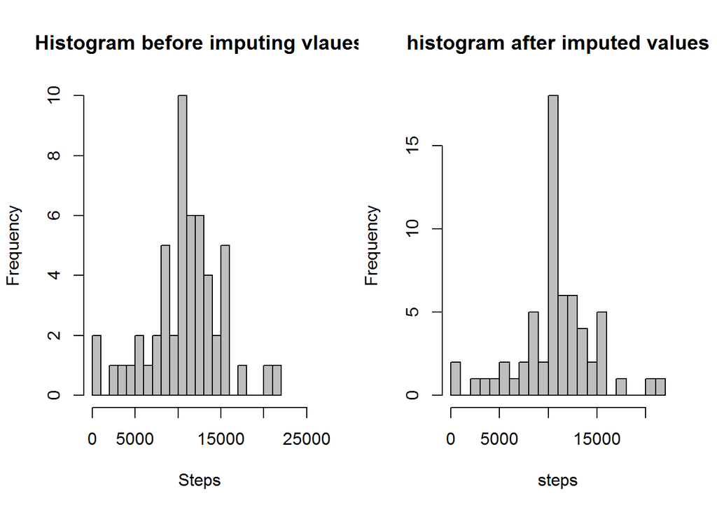

```r
steps_perday_imputed = aggregate(steps~date, data = activity_data_imputed,FUN = sum)
#Comparing the previous hist with NAs with new hist with imputed values
par(mfrow = c(1,2))
hist(steps_perday$steps, col = "grey",breaks = 16,ylim = c(0,10),xlim = c(0,25000)
                ,xlab = "Steps", main = "Histogram before imputing vlaues")
with(steps_perday_imputed,hist(steps, col = "grey", breaks = 16, xlab = "steps",
                               main = "histogram after imputed values"))
```

- Mean and median total number of steps taken per day Here, I am calculating mean and median for total steps per day before and after imputing NAs, to give you better picture of impact because of imputed values

```r
#mean of steps per day before imputing NAs
mean(steps_perday$steps)
```

```
## [1] 10766.19
```

```r
#mean of steps per day after imputing NAs
mean(steps_perday_imputed$steps)
```

```
## [1] 10766.19
```

```r
#median of steps per day before imputing NAs
median(steps_perday$steps)
```

```
## [1] 10765
```

```r
#median of steps per day after imputing NAs
median(steps_perday_imputed$steps)
```

```
## [1] 10766.19
```

[output not shown]

## Differences in activity patterns between weekdays and weekends

- Create a new factor variable in the dataset with two levels - “weekday” and “weekend” indicating whether a given date is a weekday or weekend day.

```r
activity_data_imputed$weekday = as.factor(weekdays(activity_data_imputed$date))
levels(activity_data_imputed$weekday) = list(weekday = c("Monday", "Tuesday",
                "Wednesday","Thursday","Friday"), weekend = c("Saturday","Sunday"))
str(activity_data_imputed)
```

```
## 'data.frame':    52704 obs. of  4 variables:
##  $ steps   : num  1.717 0.3396 0.1321 0.1509 0.0755 ...
##  $ date    : Date, format: "2012-10-01" "2012-10-01" ...
##  $ interval: int  0 5 10 15 20 25 30 35 40 45 ...
##  $ weekday : Factor w/ 2 levels "weekday","weekend": 1 1 1 1 1 1 1 1 1 1 ...
```

- Time series plot of 5-minute interval and average steps taken, averaged across all weekdays and weekends

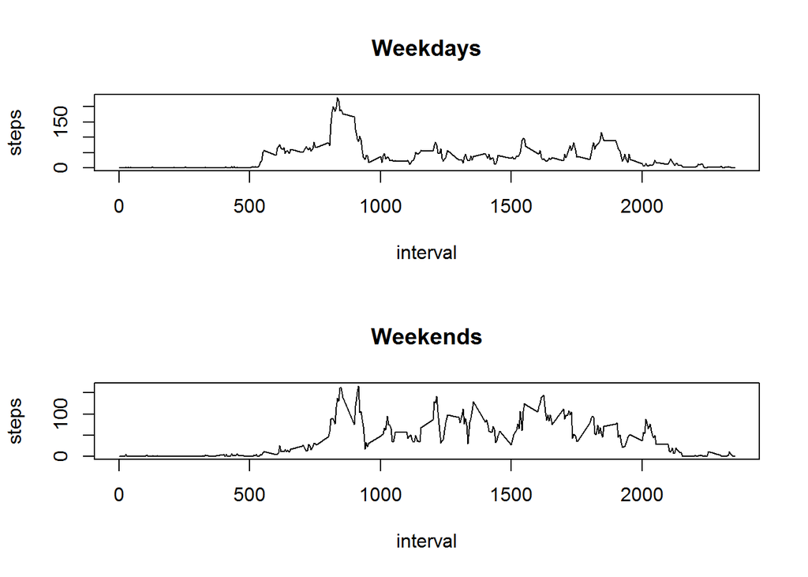

```r
par(mfrow = c(2,1))
with(activity_data_imputed[activity_data_imputed$weekday == "weekday",],
     plot(aggregate(steps~interval, FUN = mean),type = 'l', main = "Weekdays"))
with(activity_data_imputed[activity_data_imputed$weekday == "weekend",],
     plot(aggregate(steps~interval, FUN = mean),type = 'l', main = "Weekends"))
```